# Analysis of variance ANOVA

## 1.5 Estimates

```r
summary(mod)
```

```
Call:
lm(formula = Bef ~ treat, data = data)

Residuals:
   Min     1Q Median     3Q    Max
 -5.00  -2.25   0.00   2.00   4.00

Coefficients:
            Estimate Std. Error t value Pr(>|t|)
(Intercept)    11.00       1.00   11.00  3.6e-10
treatMA         4.00       1.53    2.62  0.01605
treatMP         6.00       1.34    4.47  0.00021

Residual standard error: 2.83 on 21 degrees of freedom
Multiple R-squared:  0.491, Adjusted R-squared:  0.442
F-statistic: 10.1 on 2 and 21 DF,  p-value: 0.000834
```

```r
confint(mod)
```

```
              2.5 %  97.5 %
(Intercept) 8.92039 13.0796
treatMA     0.82334  7.1767
treatMP     3.20991  8.7901
```

```r
#summary(mod0) ## The only-intercept model, uncomment if you want to look at it.
```

## 1.6 Contrasts

We want to estimate $\mu_1-\mu_2$, etc.

```r
emmeans(mod,specs=pairwise~treat,infer=TRUE) ##Estimated marginal means
```

```
$emmeans
 treat emmean    SE df lower.CL upper.CL
 M         11 1.000 21     8.92     13.1
 MA        15 1.155 21    12.60     17.4
 MP        17 0.894 21    15.14     18.9

Confidence level used: 0.95

$contrasts
 contrast estimate   SE df t.ratio p.value
 M - MA         -4 1.53 21 -2.619  0.0408
 M - MP         -6 1.34 21 -4.472  0.0006
 MA - MP        -2 1.46 21 -1.369  0.3744

P value adjustment: tukey method for comparing a family of 3 estimates
```

## 1.7 Check assumptions

In the analysis stage, however, we always have the check the assumption of **homogeneity of variance** (and normality, but less important).

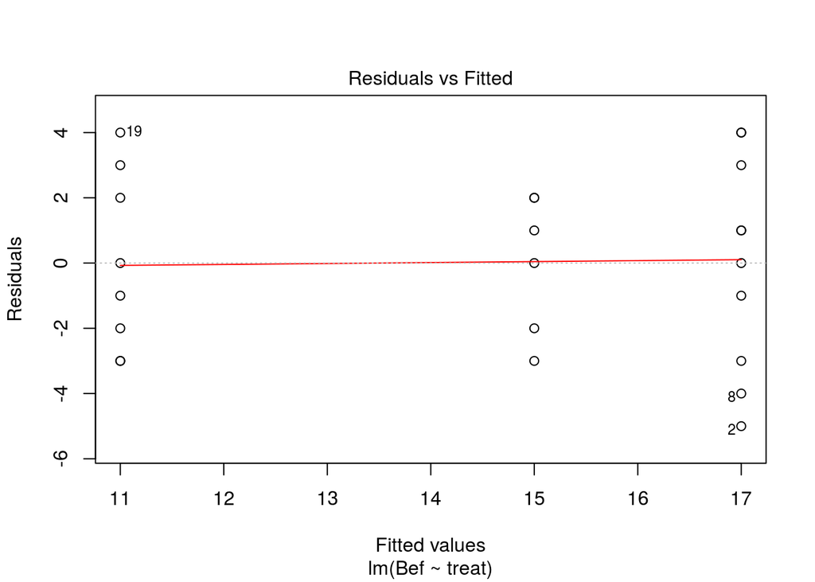

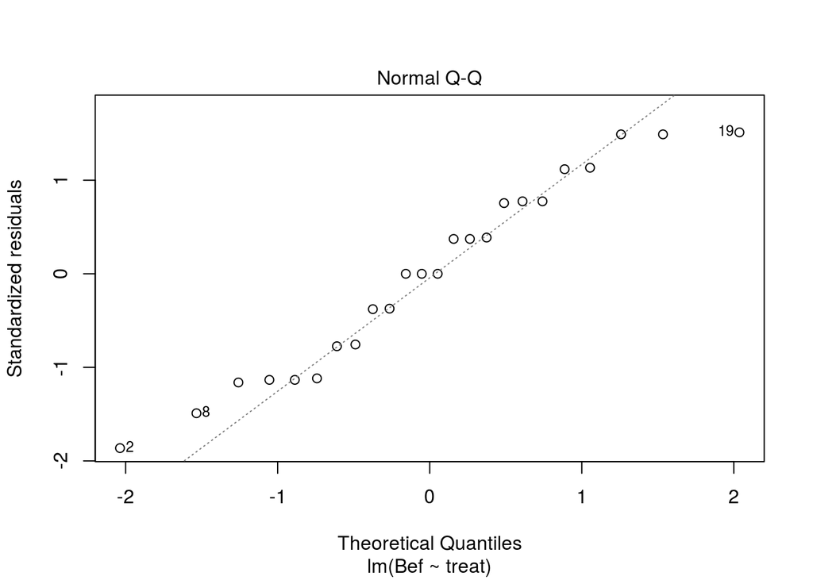

```r
plot(mod,which=c(1,2))
```

## 1.8 Classical version

`aov()` function in R:

```r
modc <-aov(Bef~treat,data)
summary(modc)
```

```
            Df Sum Sq Mean Sq F value  Pr(>F)
treat        2    162      81    10.1 0.00083
Residuals   21    168       8
```

```r
TukeyHSD(modc)
```

```
  Tukey multiple comparisons of means
    95% family-wise confidence level

Fit: aov(formula = Bef ~ treat, data = data)

$treat
      diff      lwr    upr   p adj
MA-M     4  0.14977 7.8502 0.04081
MP-M     6  2.61830 9.3817 0.00059
MP-MA    2 -1.68153 5.6815 0.37443
```

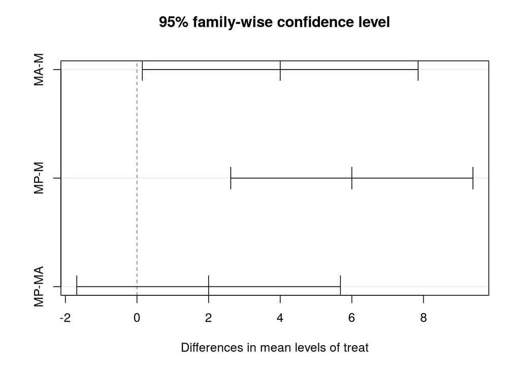

```r
plot(TukeyHSD(modc))
```

# 2 Two-factorial ANOVA

## 2.1 Statistical model

2. Effects parameterization:
   - $Y_{ijk}=\mu+\alpha_i+\beta_j+(\alpha\beta)_{ij}+\epsilon_{ijk}, \quad i=1,\ldots,I,\quad j=1,\ldots,J, \quad k=1,\ldots,n_{ij}, \quad \epsilon_{ijk}\overset{i.i.d.}{\sim} N(0,\sigma^2)$.
   - $Y_{ijk}\overset{i.i.d.}{\sim} N(\mu+\alpha_i+\beta_j+(\alpha\beta)_{ij},\sigma^2)$ (equivalent)
3. Means parameterization:
   - $Y_{ijk}=\mu_{ij}+\epsilon_{ijk}$
   - $Y_{ijk}\overset{i.i.d.}{\sim} N(\mu_{ij},\sigma^2)$ (equivalent)

## 2.2 Simulate some data

We simulate some cross-sectional data. You do not need to understand the code.

```r
nage <- 3
ntherapy <- 2
nsample <- 100
n <- nage * nsample* ntherapy
age <- gl(n = nage, k = nsample, length = n,labels=c("child","young","old"))
therapy <- gl(n = ntherapy, k = nsample, length = n,labels=c("Ctrl","Trt"))
mu <- 40
alpha <- c(1, 1)
beta <- c(1)
gamma <- c(-3,3)
parameter <- c(mu, alpha, beta, gamma)
sigma <- 12
set.seed(9)
eps <- rnorm(n, 0, sigma)
X <- as.matrix(model.matrix(~ age*therapy) )
response <- as.numeric(as.matrix(X) %*% as.matrix(parameter) + eps)
d.cross<-data.frame(response,age,therapy)
```

```r
headTail(d.cross)
```

```
    response   age therapy
1       30.8 child    Ctrl
2       30.2 child    Ctrl
3       38.3 child    Ctrl
4      36.67 child    Ctrl
...      ...  <NA>    <NA>
597    38.57   old     Trt
598    75.22   old     Trt
599    27.52   old     Trt
600    27.97   old     Trt
```

## 2.3 Two-factorial model

We begin with a cross-sectional analysis, a two-factorial *balanced* design:

```r
with(d.cross,xtabs(~age+therapy))
```

```
       therapy
age     Ctrl Trt
  child  100 100
  young  100 100
  old    100 100
```

```r
aggregate(response~therapy+age,data=d.cross,summary)
```

```
  therapy   age response.Min. response.1st Qu. response.Median response.Mean
1    Ctrl child        8.5875          31.0511         37.9505       39.3578
2     Trt child       16.9479          34.6612         42.0354       42.6000
3    Ctrl young        4.5071          34.4806         41.0679       40.9037
4     Trt young        6.1445          28.7448         39.1686       37.3866
5    Ctrl   old       11.3583          34.9932         40.3621       41.0520
6     Trt   old       15.1560          37.4397         47.1021       45.7549
  response.3rd Qu. response.Max.
1          45.0638       72.1839
2          50.3490       74.1503
3          46.9820       70.0471
4          46.3560       60.6683
5          49.4753       65.1788
6          52.9712       75.2195
```

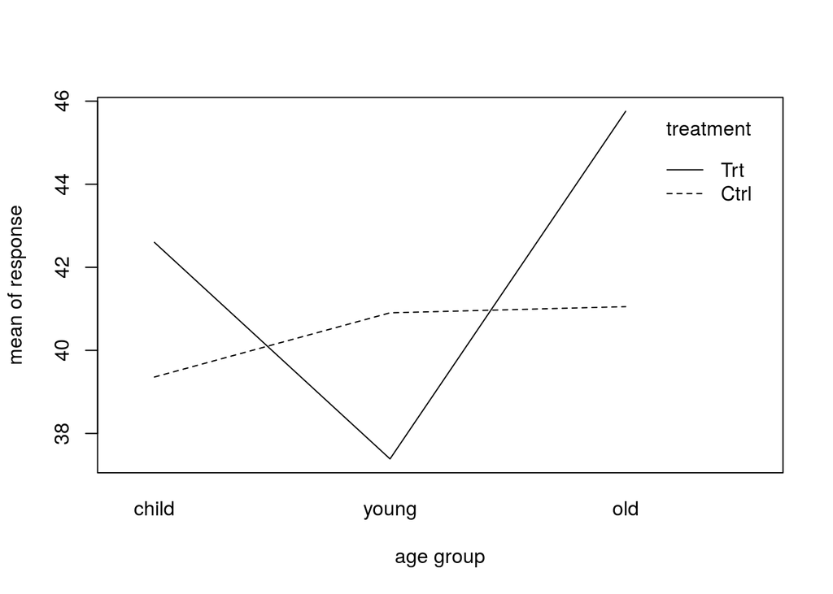

```r
with(d.cross,interaction.plot(x.factor=age,trace.factor=therapy,response=response,trace.label="treatment",xlab="age group",ylab="mean of response"))
```

```r
model2f <-lm(response~age*therapy,data=d.cross)
summary(model2f)
```

```
Call:
lm(formula = response ~ age * therapy, data = d.cross)

Residuals:
   Min     1Q Median     3Q    Max
-36.40  -7.84   0.03   7.47  32.83

Coefficients:
                    Estimate Std. Error t value Pr(>|t|)
(Intercept)            39.36       1.17   33.52   <2e-16
ageyoung                1.55       1.66    0.93   0.3522
ageold                  1.69       1.66    1.02   0.3080
therapyTrt              3.24       1.66    1.95   0.0513
ageyoung:therapyTrt    -6.76       2.35   -2.88   0.0041
ageold:therapyTrt       1.46       2.35    0.62   0.5342

Residual standard error: 11.7 on 594 degrees of freedom
Multiple R-squared:  0.0474,    Adjusted R-squared:  0.0394
F-statistic: 5.91 on 5 and 594 DF,  p-value: 2.4e-05
```

Compare to true values

```r
parameter
```

```
[1] 40  1  1  1 -3  3
```

```r
anova(model2f)
```

```
Analysis of Variance Table

Response: response
             Df Sum Sq Mean Sq F value Pr(>F)
age           2   1825     912    6.62 0.0014
therapy       1    327     327    2.37 0.1242
age:therapy   2   1923     962    6.98 0.0010
Residuals   594  81878     138
```

```r
summary(aov(response~age*therapy,data=d.cross)) ## equivalent!
```

```
             Df Sum Sq Mean Sq F value Pr(>F)
age           2   1825     912    6.62 0.0014
therapy       1    327     327    2.37 0.1242
age:therapy   2   1923     962    6.98 0.0010
Residuals   594  81878     138
```

## 2.4 Sequential versus marginal effects

**Take care**: $F$-tests in R (`anova()` and `aov()`) are **sequential** (so-called Type I sum of squares), the order the terms enter the model does matter! The $t$-tests in `lm()` on the contrary are marginal (impact of the variables, given the presence of all the other variables in the model). This is important when the design is unbalanced. (This is not the case in our example, the results do not differ). Let us change the order.

```r
summary(aov(response~therapy*age,data=d.cross)) ## equivalent!
```

```
             Df Sum Sq Mean Sq F value Pr(>F)
therapy       1    327     327    2.37 0.1242
age           2   1825     912    6.62 0.0014
therapy:age   2   1923     962    6.98 0.0010
Residuals   594  81878     138
```

If one needs so-called Type III sum of squares (marginal effects), you have to use the `Anova()` function of the package **car**.

```r
library(car)
Anova(model2f,type=3)
```

```
Anova Table (Type III tests)

Response: response
            Sum Sq  Df F value Pr(>F)
(Intercept) 154904   1 1123.79 <2e-16
age            176   2    0.64  0.528
therapy        526   1    3.81  0.051
age:therapy   1923   2    6.98  0.001
Residuals    81878 594
```